# Lithic data analysis of Jerimalai Square B

# Results: Metric and technological characteristics of cores and unretouched flakes

```r
# the table has been rearranged by hand for the paper
metrics <- flakes %>%
  group_by(phase) %>%
  summarise(median(Length, na.rm = TRUE),
            median(Width, na.rm = TRUE),
            median(Thick, na.rm = TRUE),
            median(Weight, na.rm = TRUE),
            median(Length, na.rm = TRUE),
            median(Platwid, na.rm = TRUE),
            median(Platthic, na.rm = TRUE),
            median(NoDS, na.rm = TRUE),
            median(Cortex, na.rm = TRUE),
            IQR(Length, na.rm = TRUE),
            IQR(Width, na.rm = TRUE),
            IQR(Thick, na.rm = TRUE),
            IQR(Weight, na.rm = TRUE),
            IQR(Length, na.rm = TRUE),
            IQR(Platwid, na.rm = TRUE),
            IQR(Platthic, na.rm = TRUE),
            IQR(NoDS, na.rm = TRUE),
            IQR(Cortex, na.rm = TRUE),
            n = length(Weight))

# get overhang removal data also
ohr <- filter(flakes, Overhang == "Yes") %>%
       group_by(phase) %>%
       summarise(OHR_n = length(Overhang))
# get percentages of OHR per phase
ohr$OHR_perc <- ohr$OHR_n/metrics$n * 100

# combine
metrics <- cbind(metrics, ohr[,c("OHR_n", "OHR_perc")])
metrics <- t(round(metrics,2))
# save as CSV to tidy up, there is no simple way to make the table
# that appears in the paper
write.csv(metrics, "figures/table_6_flake_metrics.csv")
# show a slightly untidy version
metrics <- data.frame(metrics)
names(metrics) <- c("phase 1", "phase 2", "phase 3", "phase 4")
kable(metrics[-1,], caption = "Summary of attributes of chert complete flakes from Jerimalai square B. Each cell contains median ± interquartile range unless otherwise indicated. ")
```

Summary of attributes of chert complete flakes from Jerimalai square B. Each cell contains median ± interquartile range unless otherwise indicated.

|  | phase 1 | phase 2 | phase 3 | phase 4 | NA |
| --- | --- | --- | --- | --- | --- |
| median(Length, na.rm = TRUE) | 9.00 | 7.99 | 9.22 | 10.44 | 6.46 |
| median(Width, na.rm = TRUE) | 8.47 | 7.78 | 8.50 | 9.71 | 6.58 |
| median(Thick, na.rm = TRUE) | 2.15 | 1.84 | 2.21 | 2.53 | 2.09 |
| median(Weight, na.rm = TRUE) | 0.18 | 0.12 | 0.19 | 0.31 | 0.11 |
| median(Platwid, na.rm = TRUE) | 6.16 | 5.92 | 6.46 | 7.18 | 5.84 |
| median(Platthic, na.rm = TRUE) | 2.21 | 1.68 | 2.16 | 2.53 | 1.87 |
| median(NoDS, na.rm = TRUE) | 4.00 | 4.00 | 4.00 | 4.00 | 3.00 |
| median(Cortex, na.rm = TRUE) | 0.00 | 0.00 | 0.00 | 0.00 | 0.00 |
| IQR(Length, na.rm = TRUE) | 7.81 | 6.61 | 6.78 | 8.95 | 4.21 |
| IQR(Width, na.rm = TRUE) | 6.87 | 5.75 | 6.79 | 7.96 | 5.25 |
| IQR(Thick, na.rm = TRUE) | 2.70 | 2.02 | 2.37 | 3.06 | 1.18 |
| IQR(Weight, na.rm = TRUE) | 0.55 | 0.37 | 0.55 | 0.91 | 0.19 |
| IQR(Platwid, na.rm = TRUE) | 5.88 | 4.80 | 5.35 | 5.67 | 3.22 |
| IQR(Platthic, na.rm = TRUE) | 2.48 | 1.81 | 2.08 | 2.67 | 1.32 |
| IQR(NoDS, na.rm = TRUE) | 2.00 | 2.00 | 2.00 | 3.00 | 2.00 |
| IQR(Cortex, na.rm = TRUE) | 0.00 | 0.00 | 0.00 | 0.00 | 0.00 |
| n | 475.00 | 371.00 | 1130.00 | 915.00 | 51.00 |
| OHR_n | 259.00 | 198.00 | 651.00 | 542.00 | 33.00 |
| OHR_perc | 54.53 | 53.37 | 57.61 | 59.23 | 64.71 |

The code chunk below uses a Bayesian one-way ANOVA to investigate differences in chert flake mass by depositional phase.

```r
myDataFrame <- data.frame(phase = flakes$phase, mass = flakes$Weight)
# remove flakes with no phase
myDataFrame <- myDataFrame[!is.na(myDataFrame$phase),]
yName = names(myDataFrame)[2] # mass
xName = names(myDataFrame)[1] # phase
contrasts = list(
  list( c("1") , c("2") , compVal=0.0 , ROPE=c(-0.1,0.1) ) ,
  list( c("2")  , c("3") , compVal=0.0 , ROPE=c(-0.1,0.1)) ,
  list( c("3")  , c("4") , compVal=0.0 , ROPE=c(-0.1,0.1)) )
# Generate the MCMC chain:
  mcmcCoda_ANOVA = genMCMC_ANOVA(datFrm=myDataFrame , yName=yName , xName=xName ,
                      numSavedSteps=11000 , thinSteps=10
                      )
```

[output not shown]

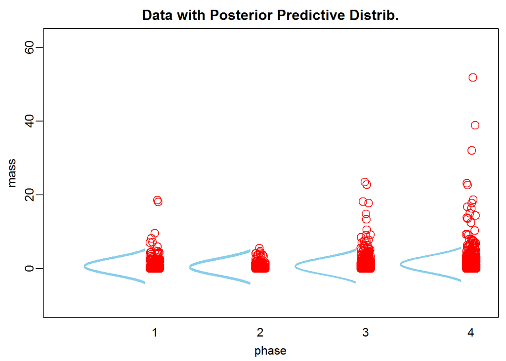

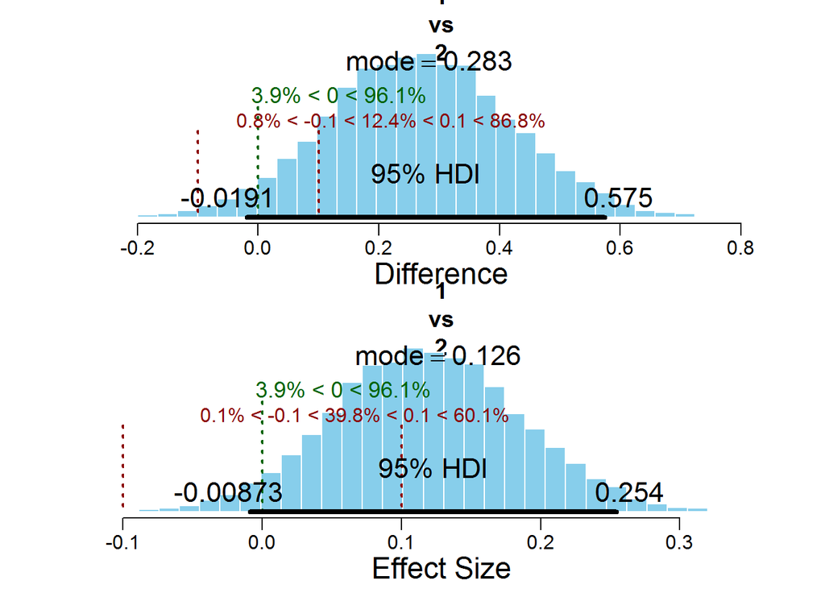

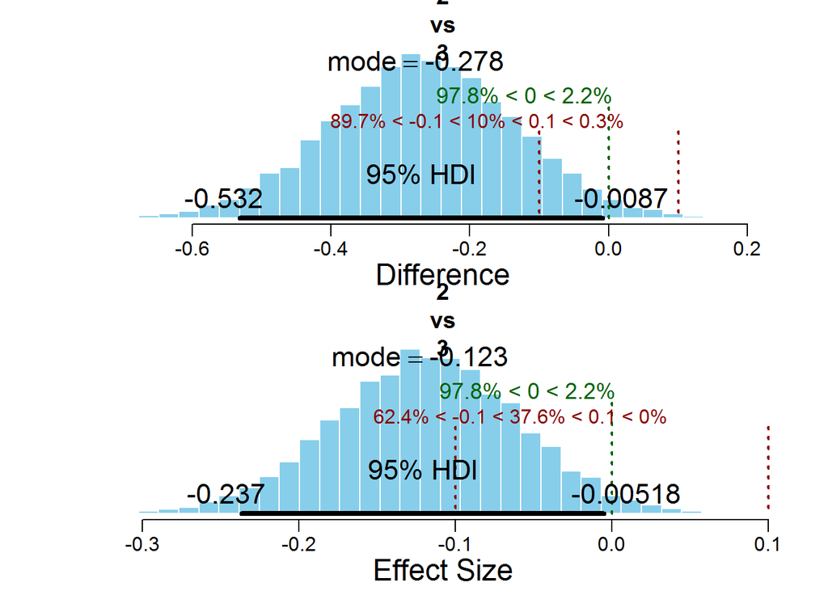

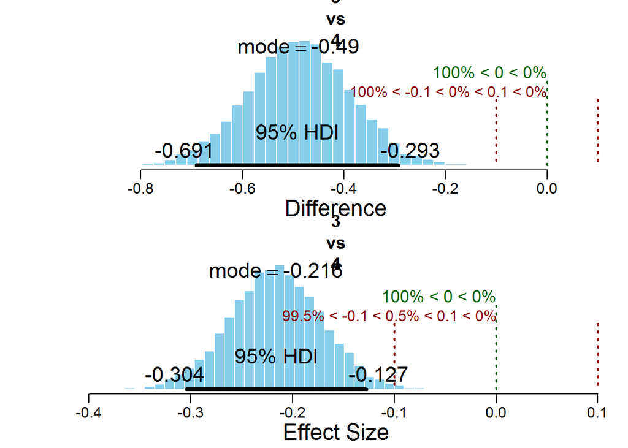

```r
  # Get summary statistics of chain:
  summaryInfo_ANOVA = smryMCMC_ANOVA( mcmcCoda_ANOVA ,
                          datFrm=myDataFrame , xName=xName ,
                          contrasts=contrasts
                          )

#  Display posterior information (not easy to read unless using interactively):
    plotMCMC_ANOVA( mcmcCoda_ANOVA ,
              datFrm=myDataFrame , yName=yName , xName=xName ,
              contrasts=contrasts  )
```

```r
# subset summaryInfo to show HDI interval for interactions
    HDI_intervals_for_interactions <- summaryInfo_ANOVA[c((nrow(summaryInfo_ANOVA)-length(contrasts)+1):nrow(summaryInfo_ANOVA)), c("HDIlow", "HDIhigh")]

kable(round(HDI_intervals_for_interactions,3), caption = "Highest density intervals (95%) for the posterior distributions of the interactions between phases and flake mass.")
```

Highest density intervals (95%) for the posterior distributions of the interactions between phases and flake mass.

|  | HDIlow | HDIhigh |
| --- | --- | --- |
| 1.v.2 | -0.019 | 0.575 |
| 2.v.3 | -0.532 | -0.009 |
| 3.v.4 | -0.691 | -0.293 |

```r
# ANOVA with Tukey's HSD
fit <- aov(Weight ~ as.factor(phase), flakes)
fit_summary <-  summary(fit)
tuk <- TukeyHSD(fit)
# plot(tuk, las = 2, cex = 0.1)
kable(round(tuk$`as.factor(phase)`,3), caption = "Tukey's Honest Significant Difference for phase by phase comparisons of flake mass.")
```

Tukey’s Honest Significant Difference for phase by phase comparisons of flake mass.

|  | diff | lwr | upr | p adj |
| --- | --- | --- | --- | --- |
| 2-1 | -0.291 | -0.694 | 0.111 | 0.245 |
| 3-1 | 0.004 | -0.314 | 0.321 | 1.000 |
| 4-1 | 0.508 | 0.180 | 0.836 | 0.000 |
| 3-2 | 0.295 | -0.052 | 0.642 | 0.128 |
| 4-2 | 0.799 | 0.442 | 1.157 | 0.000 |
| 4-3 | 0.504 | 0.246 | 0.762 | 0.000 |

The code chunk below produces a summary table of metric attributes of chert complete cores from Jerimalai square B.

```r
cores_mass <- allchert[allchert$Artclas == "core", ]
core_metrics <- cores_mass %>%
  group_by(phase) %>%
  filter(phase %in% 1:4) %>%
  summarise(median(Weight),
            median(Length),
            median(Width),
            median(Thick),
            median(as.numeric(cores_mass$NoDS)),
            median(as.numeric(cores_mass$Cortex), na.rm = TRUE),
            median(as.numeric(cores_mass$Corerot)),
            IQR(Weight),
            IQR(Length),
            IQR(Width),
            IQR(Thick),
            IQR(as.numeric(cores_mass$NoDS)),
            IQR(as.numeric(cores_mass$Cortex), na.rm = TRUE),
            IQR(as.numeric(cores_mass$Corerot)),
            n = length(Weight))
core_metrics_t <- t(round(core_metrics,2))
colnames(core_metrics_t) <- c("phase 1", "phase 2", "phase 3", "phase 4" )
kable(core_metrics_t, caption = "Summary of chert core metrics")
```

Summary of chert core metrics

|  | phase 1 | phase 2 | phase 3 | phase 4 |
| --- | --- | --- | --- | --- |
| phase | 1.00 | 2.00 | 3.00 | 4.00 |
| median(Weight) | 3.79 | 2.25 | 2.38 | 3.65 |
| median(Length) | 22.94 | 17.82 | 17.45 | 20.21 |
| median(Width) | 15.28 | 14.66 | 13.55 | 14.80 |
| median(Thick) | 10.62 | 6.75 | 8.78 | 9.56 |
| median(as.numeric(cores_mass$NoDS)) | 11.00 | 11.00 | 11.00 | 11.00 |
| median(as.numeric(cores_mass$Cortex),… | 0.00 | 0.00 | 0.00 | 0.00 |
| median(as.numeric(cores_mass$Corerot)) | 3.50 | 3.50 | 3.50 | 3.50 |
| IQR(Weight) | 7.05 | 3.70 | 2.67 | 5.83 |
| IQR(Length) | 13.46 | 8.28 | 8.66 | 11.13 |
| IQR(Width) | 10.07 | 9.59 | 5.37 | 9.18 |
| IQR(Thick) | 6.87 | 4.21 | 4.84 | 3.44 |
| IQR(as.numeric(cores_mass$NoDS)) | 5.00 | 5.00 | 5.00 | 5.00 |
| IQR(as.numeric(cores_mass$Cortex), na… | 5.00 | 5.00 | 5.00 | 5.00 |
| IQR(as.numeric(cores_mass$Corerot)) | 1.00 | 1.00 | 1.00 | 1.00 |
| n | 36.00 | 12.00 | 37.00 | 41.00 |

The code chunk below creates a figure that shows the distribution of core and complete flake mass by depositional phases

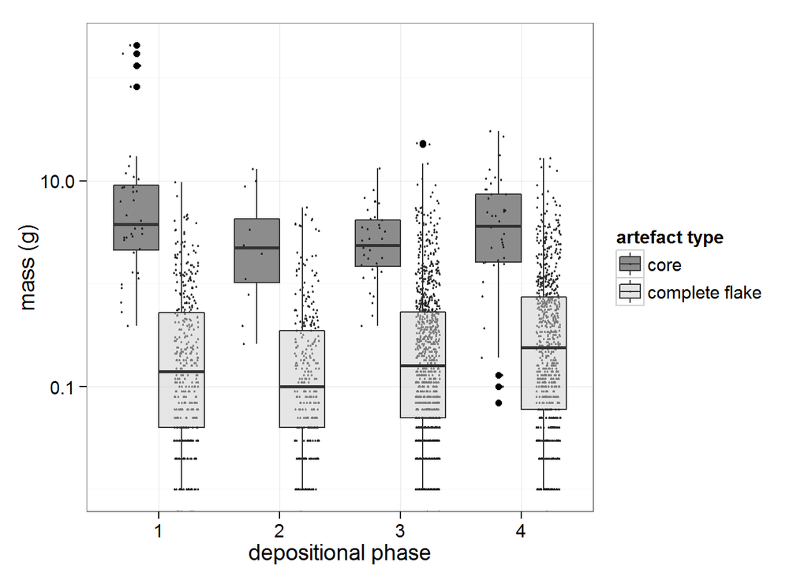

```r
# plot flake and core mass by phase in one box plot
flakes_cores_weight <- allchert %>%
                         filter(Artclas %in% c("flake", "core")) %>%
                         filter(phase %in% 1:4) %>%
                         select(Artclas, Weight, phase)


ggplot(flakes_cores_weight, aes(fill = Artclas, as.factor(phase), Weight)) +
  geom_point(aes(colour = Artclas), size = 0.5, alpha = 0.9, shape = 1,
             position=position_jitterdodge(dodge.width=0.9)) +
  geom_boxplot(alpha = 0.5) +
  scale_y_log10() +
  #theme_minimal(base_size = 4) +
  xlab('depositional phase') +
  ylab("mass (g)") +
  scale_fill_manual(name="artefact type",
                      labels=c("core", "complete flake"),
                     values = c("grey10", "grey80")) +
  scale_colour_manual(name="artefact type",
                      labels=c("core", "complete flake"),
                      values = c("grey10", "grey15"))
```

```r
# save plot
jhe_190mm_ggsave("figures/fig_6_Jeremalai-flake-core-mass-phase.png",
                height = (190/2))
```

The code chunk below uses a Bayesian one-way ANOVA to investigate differences in chert core mass by depositional phase.

```r
myDataFrame <- data.frame(phase = cores_mass$phase, mass = cores_mass$Weight)
# remove flakes with no phase
myDataFrame <- myDataFrame[!is.na(myDataFrame$phase),]
yName = names(myDataFrame)[2] # mass
xName = names(myDataFrame)[1] # phase
contrasts = list(
  list( c("1") ,  c("2") , compVal=0.0 , ROPE=c(-0.1,0.1) ) ,
  list( c("2")  , c("3") , compVal=0.0 , ROPE=c(-0.1,0.1)) ,
  list( c("3")  , c("4") , compVal=0.0 , ROPE=c(-0.1,0.1)) )
# Generate the MCMC chain:
  mcmcCoda_ANOVA = genMCMC_ANOVA(datFrm=myDataFrame , yName=yName , xName=xName ,
                      numSavedSteps=11000 , thinSteps=10
                      )
```

[output not shown]

```r
  # Get summary statistics of chain:
  summaryInfo_ANOVA = smryMCMC_ANOVA( mcmcCoda_ANOVA ,
                          datFrm=myDataFrame , xName=xName ,
                          contrasts=contrasts
                          )

# #  Display posterior information (not easy to read unless using interactively):
#     plotMCMC_ANOVA( mcmcCoda_ANOVA ,
#               datFrm=myDataFrame , yName=yName , xName=xName ,
#               contrasts=contrasts  )
#
# subset summaryInfo to show HDI interval for interactions
 HDI_intervals_for_interactions <- summaryInfo_ANOVA[c((nrow(summaryInfo_ANOVA)-length(contrasts)+1):nrow(summaryInfo_ANOVA)), c("HDIlow", "HDIhigh")]
kable(round(HDI_intervals_for_interactions,3), caption = "Highest density intervals (95%) for the posterior distributions of the interactions between phases and core mass.")
```

Highest density intervals (95%) for the posterior distributions of the interactions between phases and core mass.

|  | HDIlow | HDIhigh |
| --- | --- | --- |
| 1.v.2 | -2.219 | 29.221 |
| 2.v.3 | -13.711 | 15.416 |
| 3.v.4 | -13.233 | 8.415 |

The code chunk above produced results that indicate that the HDIs for all phases include zero, which we interpret as no credible difference. In the code chunk below we repeat the same investigation using a frequentist ANOVA.

```r
# ANOVA with Tukey's HSD
fit <- aov(mass ~ as.factor(phase), myDataFrame)
fit_summary <-  summary(fit)
tuk <- TukeyHSD(fit)
# plot(tuk, las = 2, cex = 0.1)
kable(round(tuk$`as.factor(phase)`,3), caption = "Tukey's Honest Significant Difference for phase by phase comparisons of core mass.")
```

Tukey’s Honest Significant Difference for phase by phase comparisons of core mass.

|  | diff | lwr | upr | p adj |
| --- | --- | --- | --- | --- |
| 2-1 | -17.283 | -40.336 | 5.771 | 0.212 |
| 3-1 | -17.997 | -34.187 | -1.806 | 0.023 |
| 4-1 | -15.426 | -31.223 | 0.371 | 0.058 |
| 3-2 | -0.714 | -23.690 | 22.262 | 1.000 |
| 4-2 | 1.856 | -20.843 | 24.556 | 0.997 |
| 4-3 | 2.570 | -13.112 | 18.253 | 0.974 |